# Getting the Full Picture

Craig A. Sloss

2023-07-05

# Introduction and Setup

This notebook is a supplement to the article “Getting the Full Picture” in *Questioning the Numbers*, showing the code used to generate the graphics and statistical results appearing in the article. (See https://questioning-the-numbers.ghost.io/) Section titles in this document correspond to the sections in the article. This notebook also contains some additional discussion of technical details that are not in the article.

The following packages are used in this notebook:

```r
require(tidyverse)
require(curl)
```

Download the full Uniform Crime Reporting Survey data from https://www150.statcan.gc.ca/t1/tbl1/en/tv.action?pid=3510017701:

```r
curl_download("https://www150.statcan.gc.ca/n1/tbl/csv/35100177-eng.zip", "ucr_full.zip")
unzip("ucr_full.zip")
ucr_full = read_csv("./35100177.csv")
```

Preview the data:

```r
ucr_full %>% head()
```

```
## # A tibble: 6 × 16
##   REF_DATE GEO    DGUID         Violations Statistics UOM   UOM_ID SCALAR_FACTOR
##      <dbl> <chr>  <chr>         <chr>      <chr>      <chr>  <dbl> <chr>
## 1     1998 Canada 2016A0000111… Total, al… Actual in… Numb…    223 units
## 2     1998 Canada 2016A0000111… Total, al… Rate per … Rate     257 units
## 3     1998 Canada 2016A0000111… Total, al… Percentag… Perc…    239 units
## 4     1998 Canada 2016A0000111… Total, al… Percentag… Perc…    239 units
## 5     1998 Canada 2016A0000111… Total, al… Unfounded… Numb…    223 units
## 6     1998 Canada 2016A0000111… Total, al… Percent u… Perc…    239 units
## # ℹ 8 more variables: SCALAR_ID <dbl>, VECTOR <chr>, COORDINATE <chr>,
## #   VALUE <dbl>, STATUS <chr>, SYMBOL <lgl>, TERMINATED <lgl>, DECIMALS <dbl>
```

Keep data only for Kitchener-Waterloo-Cambridge, and drop columns that are not needed for this analysis. To ensure that the results appearing in the newsletter can be replicated, limit the data to 2021 and earlier so that this gives the same results when additional years of data are added in the future:

```r
reported_crime_data = ucr_full %>%
  filter(GEO == "Kitchener-Cambridge-Waterloo, Ontario [35541]" &
           REF_DATE <= 2021) %>%
  select(REF_DATE, Violations, Statistics, VALUE)
reported_crime_data %>% head()
```

```
## # A tibble: 6 × 4
##   REF_DATE Violations                Statistics                            VALUE
##      <dbl> <chr>                     <chr>                                 <dbl>
## 1     1998 Total, all violations [0] Actual incidents                     31507
## 2     1998 Total, all violations [0] Rate per 100,000 population           7306.
## 3     1998 Total, all violations [0] Percentage change in rate               NA
## 4     1998 Total, all violations [0] Percentage contribution to the Crim…   100
## 5     1998 Total, all violations [0] Unfounded incidents                     NA
## 6     1998 Total, all violations [0] Percent unfounded                       NA
```

For comparison purposes, keep the 2022 data in a separate dataset so we can compare any pre-2022 trends to what actually happened in 2022.

```r
recent_reported_crime_data = ucr_full %>%
  filter(GEO == "Kitchener-Cambridge-Waterloo, Ontario [35541]" & REF_DATE == 2022) %>%
  select(REF_DATE, Violations, Statistics, VALUE)
recent_reported_crime_data %>% head()
```

```
## # A tibble: 6 × 4
##   REF_DATE Violations                Statistics                            VALUE
##      <dbl> <chr>                     <chr>                                 <dbl>
## 1     2022 Total, all violations [0] Actual incidents                   35950
## 2     2022 Total, all violations [0] Rate per 100,000 population         5672.
## 3     2022 Total, all violations [0] Percentage change in rate             -2.46
## 4     2022 Total, all violations [0] Percentage contribution to the Cr…   100
## 5     2022 Total, all violations [0] Unfounded incidents                  218
## 6     2022 Total, all violations [0] Percent unfounded                      0.6
```

The trend_sensitivity_test function from the notebook 01_subjectivity_in_data_analysis.Rmd will be re-used in this notebook. (See the previous notebook for a detailed discussion.) I added a “log-poisson” option to this function, to provide an option for discrete distributions, since in this notebook I look at some statistics that are counts rather than rates.

```r
trend_sensitivity_test = function(x, y, method = "log-gamma") {
  x_min = min(x)
  x_max = max(x) - 2
  x_range = x_min:x_max
  x_length = length(x_range)
  upper_ci = rep(NA, x_length)
  middle = rep(NA, x_length)
  lower_ci = rep(NA, x_length)
  data = data.frame(x, y)
  for (i in 1:x_length) {
    truncated_data = data %>%
      filter(x >= x_range[i])

    if (method == "log-gamma") {
      trend_glm = glm(y ~ x, data = truncated_data, family = Gamma(link = "log"))
    }
    else if (method == "linear") {
      trend_glm = glm(y ~ x, data = truncated_data, family = gaussian(link = "identity"))
    }
    else if (method == "log-normal") {
      trend_glm = glm(y ~ x, data = truncated_data, family = gaussian(link = "log"))
    }
    else if (method == "log-inverse-gaussian") {
      trend_glm = glm(y ~ x, data = truncated_data, family = inverse.gaussian(link = "log"))
    }
    else if (method == "log-poisson") {
      trend_glm = glm(y ~ x, data = truncated_data, family = poisson(link = "log"))
    }
    else{
      print("Error: valid methods are log-gamma, linear, log-normal, or log-inverse-gaussian")
      stop()
    }

    se = summary(trend_glm)$coefficients[2,2]
    beta = trend_glm$coefficients[2]
    if (method == "linear") {
      upper_ci[i] = beta + 2 * se
      middle[i] = beta
      lower_ci[i] = beta - 2 * se
    }
    else {
      upper_ci[i] = (exp(beta + 2 * se) - 1) * 100
      middle[i] = (exp(beta) - 1) * 100
      lower_ci[i] = (exp(beta - 2 * se) - 1) * 100
    }
  }
  trend_result_data = data.frame(x_range, upper_ci, middle, lower_ci)
  return(trend_result_data)
}
```

The function yoy_rate_change_summary_statistics is a variation on the yoy_count_change_summary_statistics function from the notebook 02_using_more_than_two_data_points.Rmd. This function calculates year-over-year changes in the rate of incidents per 100 K population, as a percentage increase or decrease, and then produces some distributional statistics related to the year-over-year changes. The inputs to this function are:

- data is a subset of the UCR data, containing the columns “Violations”, “Statistics”, and “VALUE”. It should be pre-filtered for the geographical area and years of interest.
- violation is a character string specifying the type of violation for which the statistics will be computed.

The output is a list with four items:

- mean is the average value of the year-over-year percentage change
- quantiles is a list containing the minimum, first quartile, median, third quartile, and maximum year-over-year percentage change
- mean_abs is the average size of the year-over-year change, ignoring direction
- quantiles_abs is a list containing the minimum, first quartile, median, third quartile, and maximum year-over-year percentage change, ignoring direction

```r
yoy_rate_change_summary_statistics = function(data, violation) {
  base_data = data %>%
    filter(Violations == violation & Statistics == "Rate per 100,000 population")
  change_data = base_data %>%
    left_join(base_data %>%
              mutate(REF_DATE = REF_DATE + 1) %>%
              select(REF_DATE, PREV_VALUE = VALUE)) %>%
    mutate(yoy_pct_change = (VALUE / PREV_VALUE - 1) * 100,
           size_of_change = abs(yoy_pct_change))
  return(list(mean = change_data %>% pull(yoy_pct_change) %>% mean(na.rm = TRUE),
              quantiles = quantile(change_data %>% pull(yoy_pct_change), na.rm = TRUE),
              mean_abs = change_data %>% pull(size_of_change) %>% mean(na.rm = TRUE),
              quantiles_abs = quantile(change_data %>% pull(size_of_change), na.rm = TRUE)))
}
```

# How often do we see year-over-year increases and decreases?

## Distribution of increases and decreases

Extract the year-over-year percentage changes in the rate, and create an indicator, non_decrease_yoy, which is TRUE if the rate increased or stayed the same year-over-year, and FALSE otherwise. Exclude any records that have “Total” in the name.

```r
increase_decrease_data = reported_crime_data %>%
  filter(!grepl("Total", Violations) &
           Statistics == "Percentage change in rate") %>%
  mutate(non_decrease_yoy = VALUE >= 0,
         absolute_change = abs(VALUE))
```

Number of types of violations in the original dataset:

```r
length(unique(reported_crime_data$Violations))
```

```
## [1] 314
```

Check the number of types of violations after removing “Total” entries, in each year. This is done because new types of violations have been introduced over time, and we want to identify a time period during which the number of violations being tracked has been consistent.

```r
increase_decrease_data %>%
  group_by(REF_DATE) %>%
  summarise(number_of_violations = n_distinct(Violations),
            missing_change_data = sum(is.na(VALUE)))
```

```
## # A tibble: 24 × 3
##    REF_DATE number_of_violations missing_change_data
##       <dbl>                <int>               <int>
##  1     1998                  264                 264
##  2     1999                  264                 210
##  3     2000                  264                 213
##  4     2001                  264                 211
##  5     2002                  264                 213
##  6     2003                  264                 214
##  7     2004                  264                 212
##  8     2005                  264                 208
##  9     2006                  264                 209
## 10     2007                  264                 210
## # ℹ 14 more rows
```

The number of violations for which year-over-year percentage changes are reported has varied between 1999 ad 2017, with the number of missing values ranging from 196 to 214. Given that the purpose of this analysis is to provide a rough idea of how often statistics increase or decrease on a year-over-year basis, exact consistency of the number of violations for which percentage changes are reported is not needed.

Create a dataset showing the percentage of violations that saw a year-over-year increase (or staying the same) for each year since 1999:

```r
increase_decrease_distribution = increase_decrease_data %>%
  filter(REF_DATE >= 1999) %>%
  group_by(REF_DATE) %>%
  summarise(percent_non_decrease_yoy = mean(non_decrease_yoy, na.rm = TRUE),
            percent_decrease_yoy = 1 - percent_non_decrease_yoy) %>%
  pivot_longer(cols = c("percent_non_decrease_yoy", "percent_decrease_yoy"))
increase_decrease_distribution
```

```
## # A tibble: 46 × 3
##    REF_DATE name                     value
##       <dbl> <chr>                    <dbl>
##  1     1999 percent_non_decrease_yoy 0.463
##  2     1999 percent_decrease_yoy     0.537
##  3     2000 percent_non_decrease_yoy 0.392
##  4     2000 percent_decrease_yoy     0.608
##  5     2001 percent_non_decrease_yoy 0.302
##  6     2001 percent_decrease_yoy     0.698
##  7     2002 percent_non_decrease_yoy 0.451
##  8     2002 percent_decrease_yoy     0.549
##  9     2003 percent_non_decrease_yoy 0.38
## 10     2003 percent_decrease_yoy     0.62
## # ℹ 36 more rows
```

Use a stacked area chart to visualize the split between increasing and decreasing violations over time:

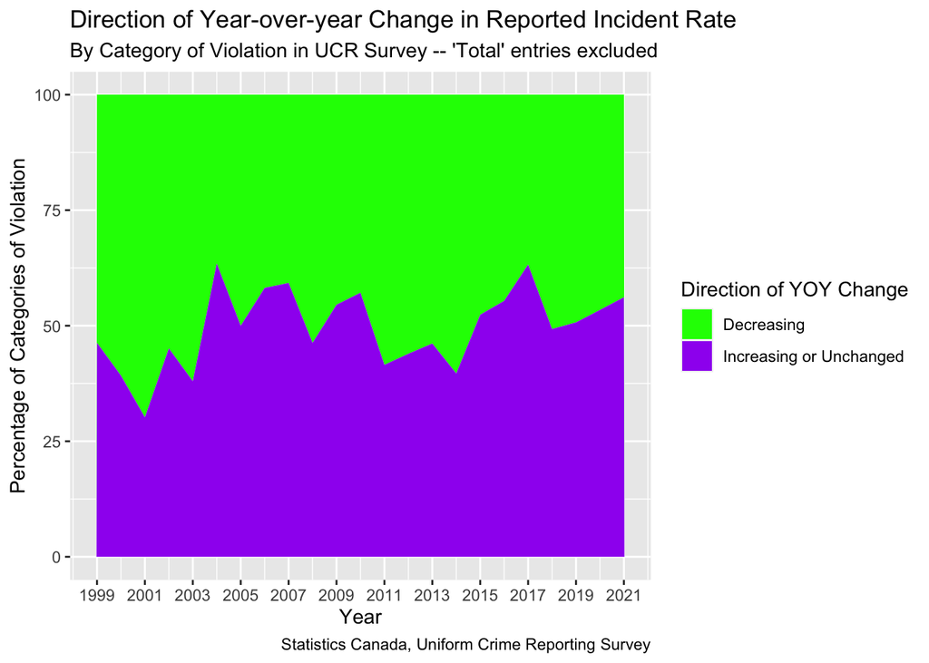

```r
ggplot(data = increase_decrease_distribution, aes(x = REF_DATE, y = value * 100, fill = name)) +
  geom_area(position = "stack") +
  scale_x_continuous(breaks = seq(1999, 2021, 2)) +
  scale_fill_discrete(name = "Direction of YOY Change", labels = c("Decreasing", "Increasing or Unchanged"), type = c("green", "purple")) +
  labs(title = "Direction of Year-over-year Change in Reported Incident Rate",
       subtitle = "By Category of Violation in UCR Survey -- 'Total' entries excluded",
       x = "Year",
       y = "Percentage of Categories of Violation",
       caption = "Statistics Canada, Uniform Crime Reporting Survey")
```

```r
ggsave("./increase_decrease_distribution_1999_2021.jpg", device = "jpeg")
ggsave("./increase_decrease_distribution_1999_2021_feature.jpg", device = "jpeg", width = 2400, height = 1200, units = "px")
ggsave("./increase_decrease_distribution_1999_2021_twitter.jpg", device = "jpeg", width = 2400, height = 1254, units = "px")
```

## Identifying potential recent trends (Supplementary Content)

This subsection contains some additional material that was not covered in the main article. It demonstrates how to quickly scan all the violations in the data to identify whether they might potentially be trending over a specified time period. The results of this function should not be viewed as definitive; its intended use is to identify violations that may be worth performing a more detailed trend analysis on (e.g. by visualizing the data, testing the sensitivity of the start year, etc.)

The inputs to this function are:

- data is a subset of the UCR data, containing the columns “Violations”, “Statistics”, “REF_DATE”, and “VALUE”. It should be pre-filtered for the geographical area.
- first_year is the earliest year that gets included in the trend analysis.
- statistic is the quantity in the “Statistics” column of the UCR data for which the trends will be calculated. Examples include “Rate per 100,000 population” and “Actual Incidents”

The output of the function is a data frame with the following columns:

- Violations is the name of the violation for which the trend calculation was performed
- multiplicative_trend is the annual multiplicative trend estimated using a log-Gamma GLM, using only data corresponding to first_year and later
- value_2021 is the value of “statistic” in 2021; this is included so that it can be used to filter out results for low-volume violations if needed
- p_values is the p-value corresponding to the multiplicative trend, as estimated by the GLM

A row in the data will only be generated for violations that have data for every year after first_year.

```r
scan_for_potential_trends = function(data, first_year, statistic) {
  trend_data = data %>%
    filter(REF_DATE >= first_year & Statistics == statistic)
  # Calculate the number of years in the data for later reference
  number_of_years = trend_data %>%
    pull(REF_DATE) %>%
    n_distinct()
  # Create empty arrays to store results
  Violations = unique(trend_data$Violations)
  multiplicative_trend = rep(NA, length(Violations))
  value_2021 = rep(NA, length(Violations))
  p_values = rep(NA, length(Violations))
  # Loop over the violations in the data; fit a log-link GLM to get multiplicative trends.
  # Store the coefficients, p-values, and value of the statistic in 2021 in the arrays
  # This is done only if the violation has data for all years after first_year; otherwise NA is output
  for (i in 1:(length(Violations))) {
    trend_data_current = trend_data %>% filter(VALUE > 0 & Violations == Violations[i])
    if (nrow(trend_data_current) == number_of_years) {
      trend_glm = glm(VALUE ~ REF_DATE, data = trend_data_current, family = Gamma(link = "log"))
      multiplicative_trend[i] = exp(trend_glm$coefficients[2])
      value_2021[i] = trend_data %>% filter(REF_DATE == 2021 & Violations == Violations[i]) %>%
      pull(VALUE)
      p_values[i] = summary(trend_glm)$coefficients[2,4]
    } else {
      multiplicative_trend[i] = NA
      value_2021[i] = NA
      p_values[i] = NA
    }
  }
  # Assemble the arrays into a data frame; remove missing values and sort by the size of the trend
  trend_results = data.frame(Violations = Violations, multiplicative_trend = multiplicative_trend, value_2021 = value_2021, p_values = p_values) %>%
    filter(!is.na(multiplicative_trend)) %>%
    arrange(multiplicative_trend)
  return(trend_results)
}
```

Find some examples of types of violations that may have medium-term trends over the past 8 years. Limit the output to violations having small p-values, and at least 20 incidents per 100K population in 2021.

```r
medium_term_trends = scan_for_potential_trends(data = reported_crime_data,
                                               first_year = 2014,
                                               statistic = "Rate per 100,000 population")
medium_term_trends %>%
    filter(p_values < 0.05 & value_2021 >= 20)
```

```
##                                                                  Violations
## 1                                    Total Federal Statute violations [400]
## 2                                               Total drug violations [401]
## 3                                 Operation while impaired (alcohol) [9230]
## 4                                              Total impaired driving [910]
## 5                                              Theft $5,000 or under [2140]
## 6                              Total Criminal Code traffic violations [900]
## 7                                     Total property crime violations [200]
## 8                                                 Total, all violations [0]
## 9                          Total violations related to animal cruelty [335]
## 10             Total, all Criminal Code violations (including traffic) [25]
## 11                  Other offences against the person and reputation [3772]
## 12             Total, all Criminal Code violations (excluding traffic) [50]
## 13 Wilful and forbidden acts in respect of certain material property [3811]
## 14                                               Criminal harassment [1625]
```

[output cut: 51 more lines]

This is the approach I used to identify that there was a potential medium-term decreasing trend in “Theft $5,000 or under”, which I investigated in detail in 01_subjectivity_in_data_analysis.Rmd.

Find some examples of types of violations that may have short-term trends over the past 4 years. Limit the output to violations having small p-values, and at least 20 incidents per 100K population in 2021.

```r
short_term_trends = scan_for_potential_trends(data = reported_crime_data,
                                               first_year = 2018,
                                               statistic = "Rate per 100,000 population")
short_term_trends %>%
  filter(p_values < 0.05 & value_2021 >= 20)
```

```
##                                        Violations multiplicative_trend
## 1                      Breach of probation [3520]            0.6679974
## 2       Operation while impaired (alcohol) [9230]            0.8331547
## 3                    Possession of weapons [3375]            1.0344345
## 4    Total violent Criminal Code violations [100]            1.0635228
## 5                         Uttering threats [1627]            1.1120017
## 6  Assault, level 2, weapon or bodily harm [1420]            1.1356254
## 7                           Identity fraud [2166]            1.1644962
## 8                        Trespass at night [3490]            1.4492633
## 9                        Theft over $5,000 [2130]            1.5447091
## 10                          Identity theft [2165]            1.8361983
##    value_2021     p_values
## 1       69.37 0.0004781303
## 2       45.65 0.0260333337
## 3       34.69 0.0261877181
## 4     1443.44 0.0234722027
## 5      264.08 0.0009842342
## 6      222.85 0.0180099691
## 7      146.77 0.0250814427
## 8       53.99 0.0259420106
## 9       96.70 0.0260868087
## 10      98.99 0.0215247953
```

This suggests that Breach of Probation may be an example of a violation exhibiting a short-term decreasing trend.

## Breach of Probation

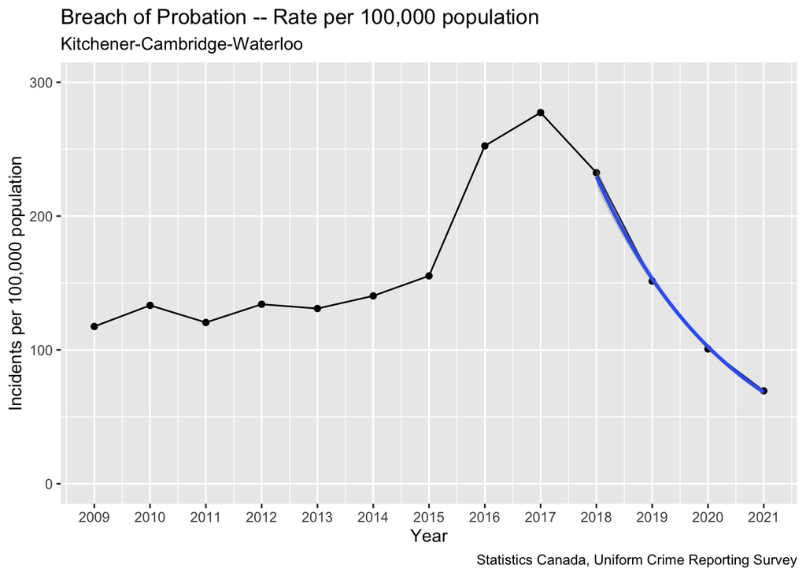

```r
bop_data = reported_crime_data %>% filter(REF_DATE >= 2009 & Violations == "Breach of probation [3520]" & Statistics == "Rate per 100,000 population")
ggplot(data = bop_data, aes(x = REF_DATE, y = VALUE)) +
  geom_line() +
  geom_point() +
  coord_cartesian(ylim = c(0, 300)) +
  geom_smooth(data = bop_data %>% filter(REF_DATE >= 2018), method = "glm", method.args = list(family = Gamma(link = "log"))) +
  scale_x_continuous(breaks = seq(2009, 2021, 1)) +
  labs(title = "Breach of Probation -- Rate per 100,000 population",
       subtitle = "Kitchener-Cambridge-Waterloo",
       x = "Year",
       y = "Incidents per 100,000 population",
       caption = "Statistics Canada, Uniform Crime Reporting Survey")
```

```r
ggsave("./breach_of_probation_2009_2021.jpg", device = "jpeg")
```

What was the value of this statistic in 2022?

```r
recent_reported_crime_data %>%
  filter(Violations == "Breach of probation [3520]" &
           Statistics == "Rate per 100,000 population") %>%
  pull(VALUE)
```

```
## [1] 75.1
```

This is slightly higher than the value of the statistic in 2021 (69.4), suggesting that the trend is no longer consistently going downward.

# Reported Crime Rates Showing No Evidence of Trend

Investigate three of the types of violations that were not included in Appendix C of the WRPS memo to see whether data prior to 2021 suggests evidence of a trend. Check the distribution of year-over-year numbers as well to get an idea for how volatile these numbers are for each type of violation.

## Breaking and Entering

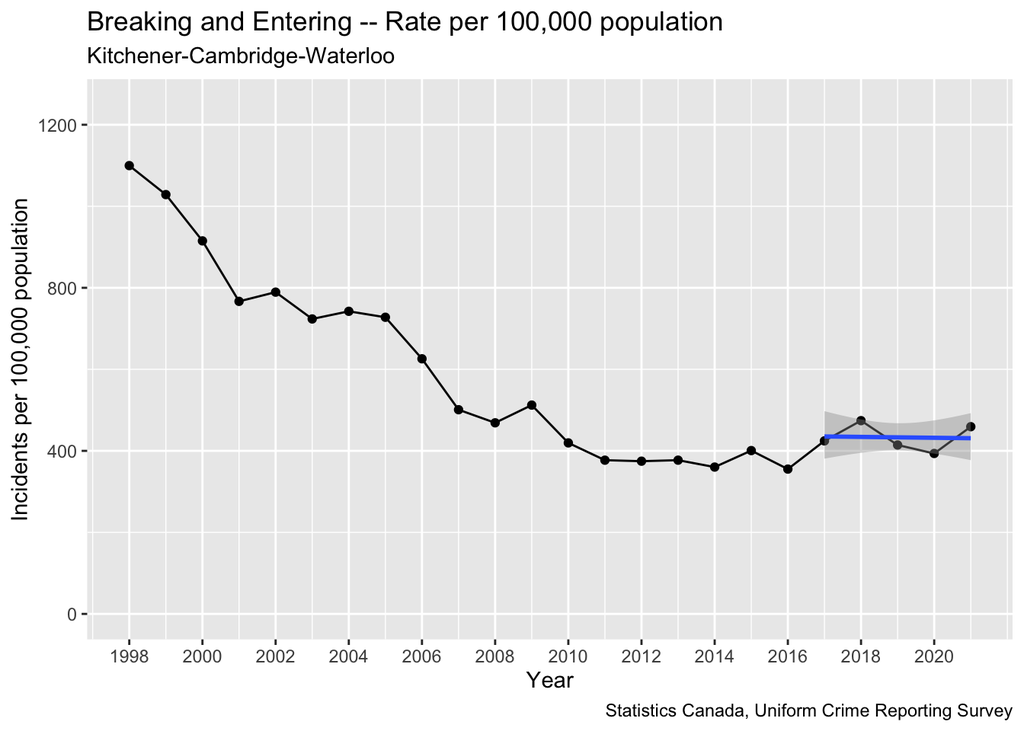

```r
b_and_e_data = reported_crime_data %>%
  filter(Violations == "Total breaking and entering [210]" & Statistics == "Rate per 100,000 population")
ggplot(data = b_and_e_data, aes(x = REF_DATE, y = VALUE)) +
  geom_line() +
  geom_point() +
  geom_smooth(data = b_and_e_data %>% filter(REF_DATE >= 2017), method = "glm", method.args = list(family = Gamma(link = "log"))) +
  scale_x_continuous(breaks = seq(1998, 2021, 2)) +
  coord_cartesian(ylim = c(0, 1250)) +
  labs(title = "Breaking and Entering -- Rate per 100,000 population",
       subtitle = "Kitchener-Cambridge-Waterloo",
       x = "Year",
       y = "Incidents per 100,000 population",
       caption = "Statistics Canada, Uniform Crime Reporting Survey")
```

```r
ggsave("./break_and_enter_1998_2021.jpg", device = "jpeg")
b_and_e_change_summary = yoy_rate_change_summary_statistics(data = reported_crime_data %>%
                                                              filter(REF_DATE >= 1998 & REF_DATE <= 2021),
                                                            violation = "Total breaking and entering [210]")
b_and_e_change_summary$mean_abs
```

```
## [1] 9.620846
```

```r
b_and_e_change_summary$quantiles_abs
```

```
##        0%       25%       50%       75%      100%
##  0.652295  4.752185 10.106548 13.299984 19.962931
```

Half the time, the year-over-year change is above 10%.

Check sensitivity of the decision to start the trend line from 2017:

```r
trend_result_data_b_and_e = trend_sensitivity_test(x = b_and_e_data %>% pull(REF_DATE),
                                           y = b_and_e_data %>% pull(VALUE),
                                           method = "log-gamma") %>%
  rename(years = x_range)
trend_result_data_b_and_e
```

```
##    years    upper_ci     middle    lower_ci
## 1   1998 -3.18840957 -4.2212456  -5.2430627
## 2   1999 -2.90301824 -3.9869730  -5.0588269
## 3   2000 -2.57983843 -3.7092740  -4.8256154
## 4   2001 -2.25608861 -3.4550020  -4.6392097
## 5   2002 -2.01581578 -3.3369668  -4.6403043
## 6   2003 -1.63419244 -3.0670748  -4.4790845
## 7   2004 -1.22562254 -2.8021902  -4.3535938
## 8   2005 -0.63227879 -2.2895441  -3.9191694
## 9   2006  0.06691369 -1.4879890  -3.0187306
## 10  2007  0.73745814 -0.6997126  -2.1163799
## 11  2008  1.29614520 -0.2841290  -1.8397500
## 12  2009  1.90408524  0.1121848  -1.6482065
## 13  2010  2.69977778  1.2730913  -0.1337758
## 14  2011  3.39436675  1.9314206   0.4891740
## 15  2012  3.94746150  2.1826328   0.4477675
## 16  2013  4.60472016  2.4028747   0.2473762
## 17  2014  5.49027869  2.6496840  -0.1144205
## 18  2015  5.81309576  2.1189133  -1.4462967
## 19  2016  7.87106637  2.6101997  -2.3940948
## 20  2017  5.45662043 -0.2456876  -5.6396572
## 21  2018  8.15834876 -1.4066724 -10.1258077
## 22  2019 18.31278107  5.2822349  -6.3131736
```

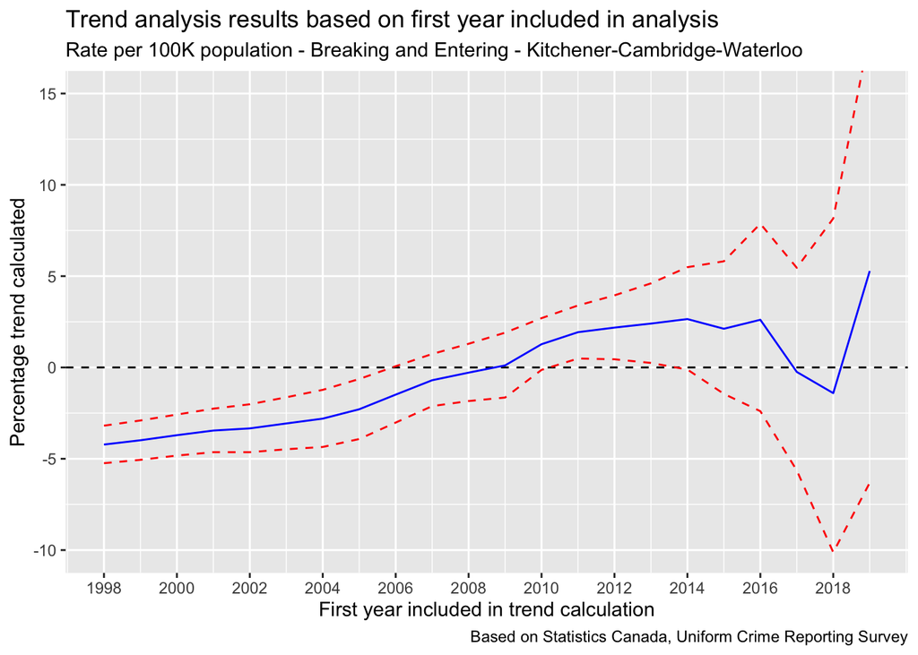

```r
ggplot(trend_result_data_b_and_e, aes(x = years, y = middle)) +
  geom_hline(yintercept = 0, colour = "black", linetype = "dashed") +
  geom_line(colour = "blue") +
  geom_line(aes(y = upper_ci), colour = "red", linetype = "dashed") +
  geom_line(aes(y = lower_ci), colour = "red", linetype = "dashed") +
  scale_x_continuous(breaks = seq(1998, 2019, 2)) +
  coord_cartesian(ylim = c(-10, 15)) +
  labs(title = "Trend analysis results based on first year included in analysis",
       subtitle = "Rate per 100K population - Breaking and Entering - Kitchener-Cambridge-Waterloo",
       x = "First year included in trend calculation",
       y = "Percentage trend calculated",
       caption = "Based on Statistics Canada, Uniform Crime Reporting Survey")
```

```r
ggsave("./b_and_e_trend_sensitivity_analysis.jpg", device = "jpeg")
```

What was the value of this statistic in 2022?

```r
recent_reported_crime_data %>%
  filter(Violations == "Total breaking and entering [210]" &
           Statistics == "Rate per 100,000 population") %>%
  pull(VALUE)
```

```
## [1] 438.92
```

This value is lower than the 2021 value (459.3), consistent with the conclusion that the value of this statistic has levelled off in recent years. Between 2017 and 2021, this statistic has ranged between 393 and 474.

## Motor Vehicle Theft

The data look essentially flat from 2015 onward:

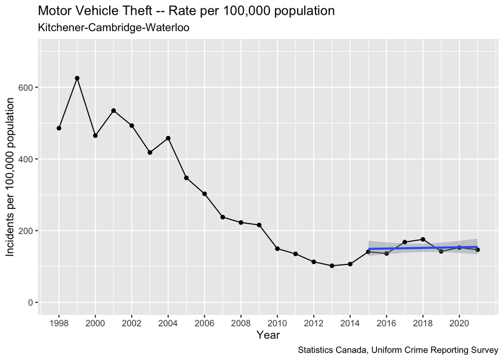

```r
motor_vehicle_theft_data = reported_crime_data %>%
  filter(Violations == "Total theft of motor vehicle [220]" & Statistics == "Rate per 100,000 population")
ggplot(data = motor_vehicle_theft_data, aes(x = REF_DATE, y = VALUE)) +
  geom_line() +
  geom_point() +
  geom_smooth(data = motor_vehicle_theft_data %>% filter(REF_DATE >= 2015), method = "glm", method.args = list(family = Gamma(link = "log"))) +
  scale_x_continuous(breaks = seq(1998, 2021, 2)) +
  coord_cartesian(ylim = c(0, 700)) +
  labs(title = "Motor Vehicle Theft -- Rate per 100,000 population",
       subtitle = "Kitchener-Cambridge-Waterloo",
       x = "Year",
       y = "Incidents per 100,000 population",
       caption = "Statistics Canada, Uniform Crime Reporting Survey")
```

```r
ggsave("./motor_vehicle_theft_1998_2021.jpg", device = "jpeg")
motor_vehicle_theft_change_summary = yoy_rate_change_summary_statistics(data = reported_crime_data %>%
                                                              filter(REF_DATE >= 1998 & REF_DATE <= 2021),
                                                            violation = "Total theft of motor vehicle [220]")
motor_vehicle_theft_change_summary$mean_abs
```

```
## [1] 14.52628
```

```r
motor_vehicle_theft_change_summary$quantiles_abs
```

```
##        0%       25%       50%       75%      100%
##  3.080516  6.765407 12.814309 22.307307 32.295866
```

Half the time, the year-over-year change is above 12.8%.

Check sensitivity of the results to the decision to start the trend line from 2015:

```r
trend_result_data_motor_vehicle_theft = trend_sensitivity_test(x = motor_vehicle_theft_data %>% pull(REF_DATE),
                                           y = motor_vehicle_theft_data %>% pull(VALUE),
                                           method = "log-gamma") %>%
  rename(years = x_range)
trend_result_data_motor_vehicle_theft
```

```
##    years   upper_ci      middle    lower_ci
## 1   1998 -5.2613919 -6.77569773  -8.2657988
## 2   1999 -5.2089705 -6.85403394  -8.4705479
## 3   2000 -4.8208256 -6.59845683  -8.3428878
## 4   2001 -4.5970618 -6.55702002  -8.4767129
## 5   2002 -4.0720521 -6.20510686  -8.2907310
## 6   2003 -3.4277757 -5.74415309  -8.0049699
## 7   2004 -2.7424236 -5.30782425  -7.8055564
## 8   2005 -1.7054812 -4.25289986  -6.7342991
## 9   2006 -0.6678461 -3.34354470  -5.9471684
## 10  2007  0.5087975 -2.24477883  -4.9229171
## 11  2008  1.6982833 -1.35182457  -4.3104545
## 12  2009  3.2169033 -0.07370324  -3.2594036
## 13  2010  4.8408844  2.18150655  -0.4104139
## 14  2011  6.2635828  3.43155720   0.6750077
## 15  2012  7.8209372  4.67411624   1.6191372
## 16  2013  8.7335842  4.76787371   0.9467998
## 17  2014  7.7909951  3.28114195  -1.0400240
## 18  2015  4.6758584  0.58663292  -3.3428445
## 19  2016  4.8202847 -0.53429847  -5.6153510
## 20  2017  0.3111293 -4.03983758  -8.2020825
## 21  2018  2.7632791 -4.66276422 -11.5521750
## 22  2019  8.2138489  1.54777742  -4.7076580
```

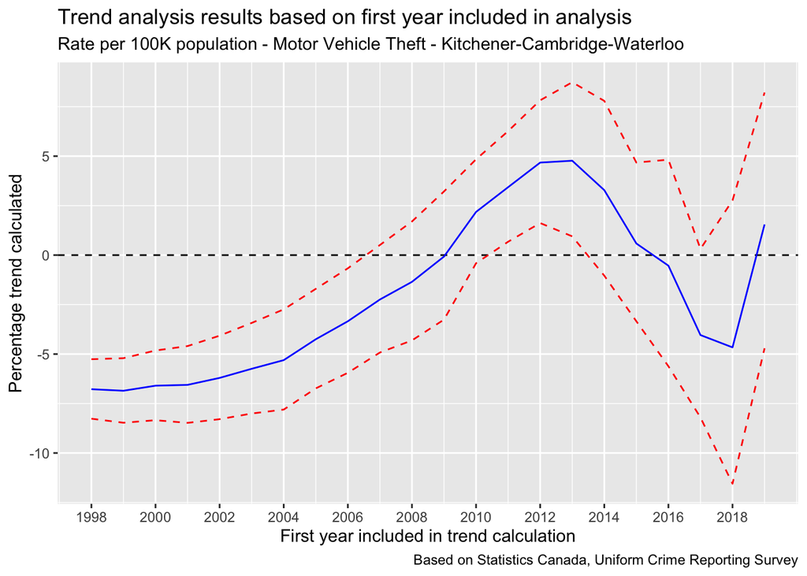

```r
ggplot(trend_result_data_motor_vehicle_theft, aes(x = years, y = middle)) +
  geom_hline(yintercept = 0, colour = "black", linetype = "dashed") +
  geom_line(colour = "blue") +
  geom_line(aes(y = upper_ci), colour = "red", linetype = "dashed") +
  geom_line(aes(y = lower_ci), colour = "red", linetype = "dashed") +
  scale_x_continuous(breaks = seq(1998, 2019, 2)) +
  labs(title = "Trend analysis results based on first year included in analysis",
       subtitle = "Rate per 100K population - Motor Vehicle Theft - Kitchener-Cambridge-Waterloo",
       x = "First year included in trend calculation",
       y = "Percentage trend calculated",
       caption = "Based on Statistics Canada, Uniform Crime Reporting Survey")
```

```r
ggsave("./motor_vehicle_theft_trend_sensitivity_analysis.jpg", device = "jpeg")
```

There is considerable uncertainty in recent years over whether the pattern is increasing or decreasing, so a flat trend line is a reasonable conclusion.

What was the value of this statistic in 2022?

```r
recent_reported_crime_data %>%
  filter(Violations == "Total theft of motor vehicle [220]" &
           Statistics == "Rate per 100,000 population") %>%
  pull(VALUE)
```

```
## [1] 174.18
```

The value of this statistic has ranged between 136 and 175 in the time period between 2015 and 2021, so the 2022 value is consistent with the conclusion that the rate has stabilized within this range.

## Robbery

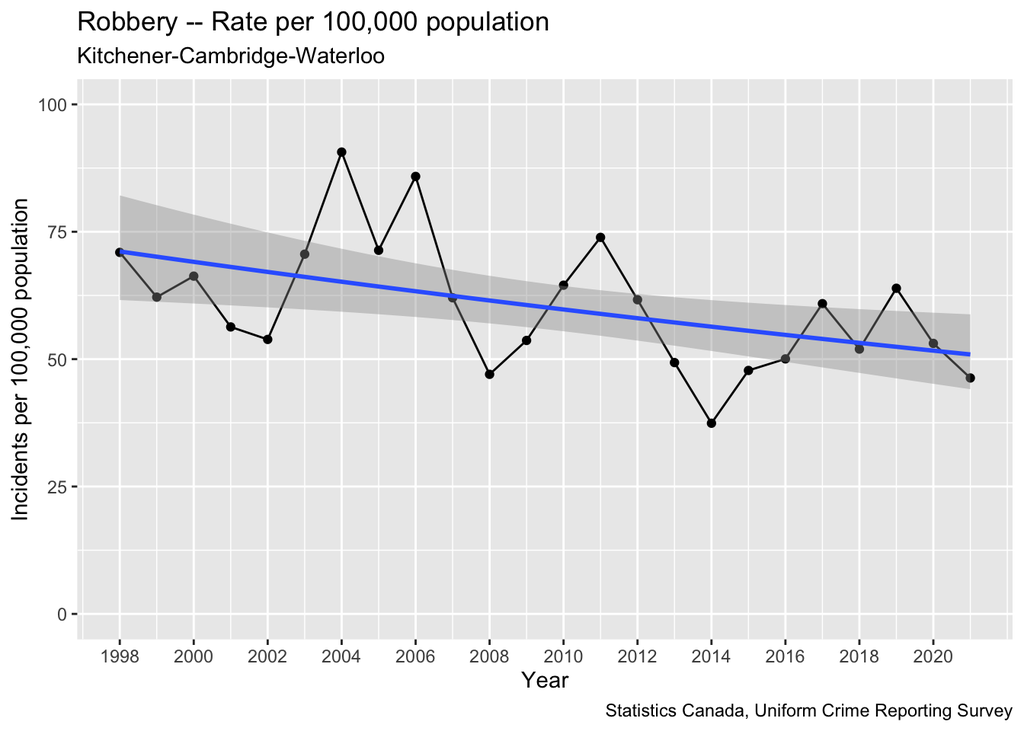

```r
robbery_data = reported_crime_data %>%
  filter(Violations == "Total robbery [160]" & Statistics == "Rate per 100,000 population")
ggplot(data = robbery_data, aes(x = REF_DATE, y = VALUE)) +
  geom_line() +
  geom_point() +
  geom_smooth(data = robbery_data %>% filter(REF_DATE >= 1998), method = "glm", method.args = list(family = Gamma(link = "log"))) +
  scale_x_continuous(breaks = seq(1998, 2021, 2)) +
  coord_cartesian(ylim = c(0, 100)) +
  labs(title = "Robbery -- Rate per 100,000 population",
       subtitle = "Kitchener-Cambridge-Waterloo",
       x = "Year",
       y = "Incidents per 100,000 population",
       caption = "Statistics Canada, Uniform Crime Reporting Survey")
```

```r
ggsave("./robbery_1998_2021.jpg", device = "jpeg")
robbery_change_summary = yoy_rate_change_summary_statistics(data = reported_crime_data %>%
                                                              filter(REF_DATE >= 1998 & REF_DATE <= 2021),
                                                            violation = "Total robbery [160]")
robbery_change_summary$mean_abs
```

```
## [1] 18.36589
```

```r
robbery_change_summary$quantiles_abs
```

```
##        0%       25%       50%       75%      100%
##  4.350142 14.349400 19.996756 23.559158 31.056247
```

Half the time, the year-over-year change is above 20%.

```r
trend_result_data_robbery= trend_sensitivity_test(x = robbery_data %>% pull(REF_DATE),
                                           y = robbery_data %>% pull(VALUE),
                                           method = "log-gamma") %>%
  rename(years = x_range)
trend_result_data_robbery
```

```
##    years    upper_ci      middle   lower_ci
## 1   1998  -0.3593497  -1.4427853  -2.514440
## 2   1999  -0.2633274  -1.4458196  -2.614292
## 3   2000  -0.3204087  -1.5915869  -2.846554
## 4   2001  -0.2891459  -1.6767000  -3.044945
## 5   2002  -0.5192748  -1.9750645  -3.409550
## 6   2003  -0.8869490  -2.3764657  -3.843597
## 7   2004  -0.8015255  -2.4574925  -4.085816
## 8   2005  -0.1721703  -1.9487398  -3.693693
## 9   2006   0.2191626  -1.8033925  -3.785130
## 10  2007   1.1677929  -0.8790794  -2.884538
## 11  2008   1.7010091  -0.6711542  -2.987987
## 12  2009   1.2568081  -1.3011789  -3.794545
## 13  2010   1.2195873  -1.7061962  -4.547409
## 14  2011   2.1818419  -1.3596415  -4.778382
## 15  2012   4.2072946   0.5088389  -3.058354
## 16  2013   6.4377256   2.4167576  -1.452308
## 17  2014   8.3698899   3.1850827  -1.751665
## 18  2015   5.5925461   0.3372129  -4.656563
## 19  2016   4.8197893  -1.6882998  -7.792312
## 20  2017   2.1685019  -5.1413887 -11.928276
## 21  2018   7.5123485  -5.4128558 -16.784184
## 22  2019 -12.4709111 -14.8850033 -17.232514
```

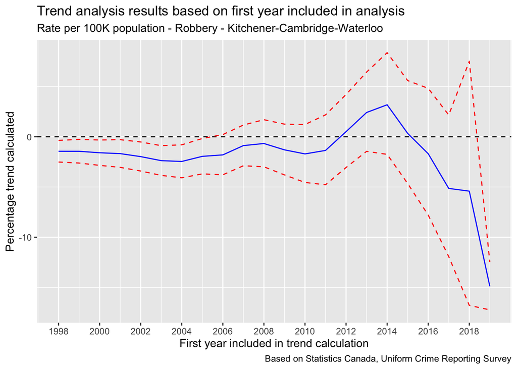

```r
ggplot(trend_result_data_robbery, aes(x = years, y = middle)) +
  geom_hline(yintercept = 0, colour = "black", linetype = "dashed") +
  geom_line(colour = "blue") +
  geom_line(aes(y = upper_ci), colour = "red", linetype = "dashed") +
  geom_line(aes(y = lower_ci), colour = "red", linetype = "dashed") +
  scale_x_continuous(breaks = seq(1998, 2019, 2)) +
  labs(title = "Trend analysis results based on first year included in analysis",
       subtitle = "Rate per 100K population - Robbery - Kitchener-Cambridge-Waterloo",
       x = "First year included in trend calculation",
       y = "Percentage trend calculated",
       caption = "Based on Statistics Canada, Uniform Crime Reporting Survey")
```

```r
ggsave("./robbery_trend_sensitivity_analysis.jpg", device = "jpeg")
```

The long term trend seems to be the only reliable thing we can say about this data – there is significant variation around the trend line, but the variation appears to be around a mean that has been decreasing over time.

What was the value of this statistic in 2022?

```r
recent_reported_crime_data %>%
  filter(Violations == "Total robbery [160]" &
           Statistics == "Rate per 100,000 population") %>%
  pull(VALUE)
```

```
## [1] 61.06
```